## Homework Week 1

**Question 1:** Suppose the globe tossing question (Chapter 2) had turned out to be 4 water and 11 land. Construct the posterior distribution, using grid approximation. Use the same flat prior as in the book.

Response: To change the observations and get a new posterior based on a different dataset, adjust the likelihood

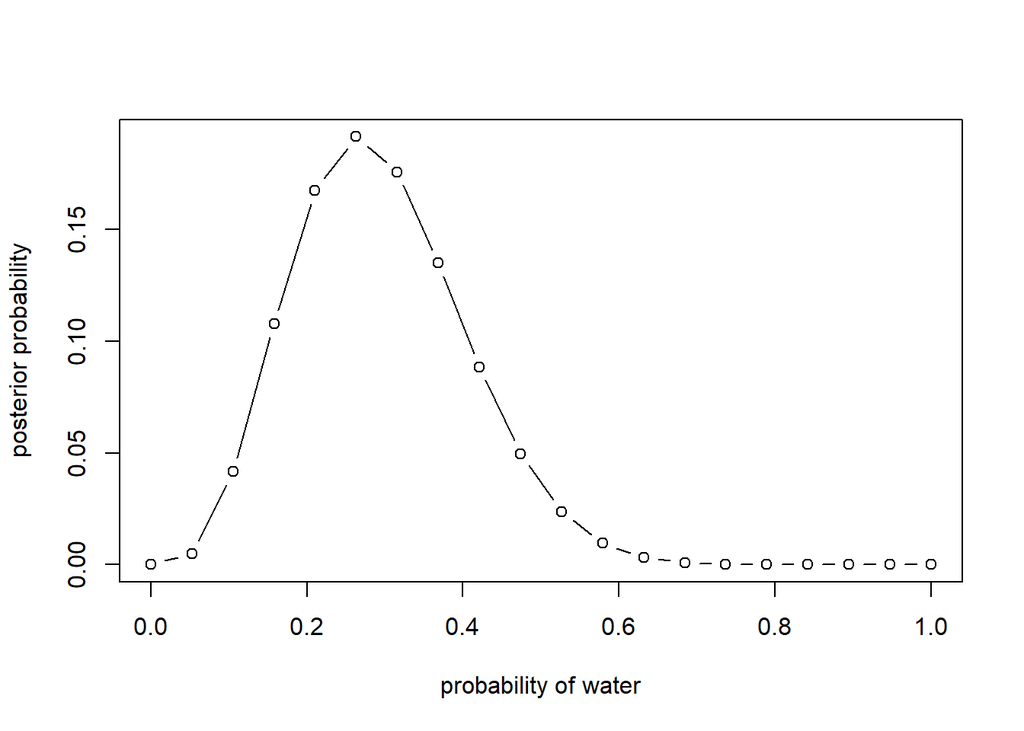

```r
# define grid
p_grid <- seq(from = 0, to = 1, length.out = 20)
# define uniform prior
prior <- rep(1,20)
# compute likelihood at each value in grid
likelihood <- dbinom(4, size = 15, prob = p_grid)
# compute likelihood of likelihood and prior
unstd.posterior <- likelihood * prior
# standardize posterior
posterior <- unstd.posterior/sum(unstd.posterior)
# plot
plot(p_grid, posterior, type = "b",
     xlab = "probability of water", ylab = "posterior probability")
```

**Question 2:** Now suppose the data are 4 water and 2 land. Compute the posterior again but this time use a prior that is zero below *p* = 0.5 and a constant above *p* = 0.5. This corresponds to prior information that a majority of the Earth’s surface is water.

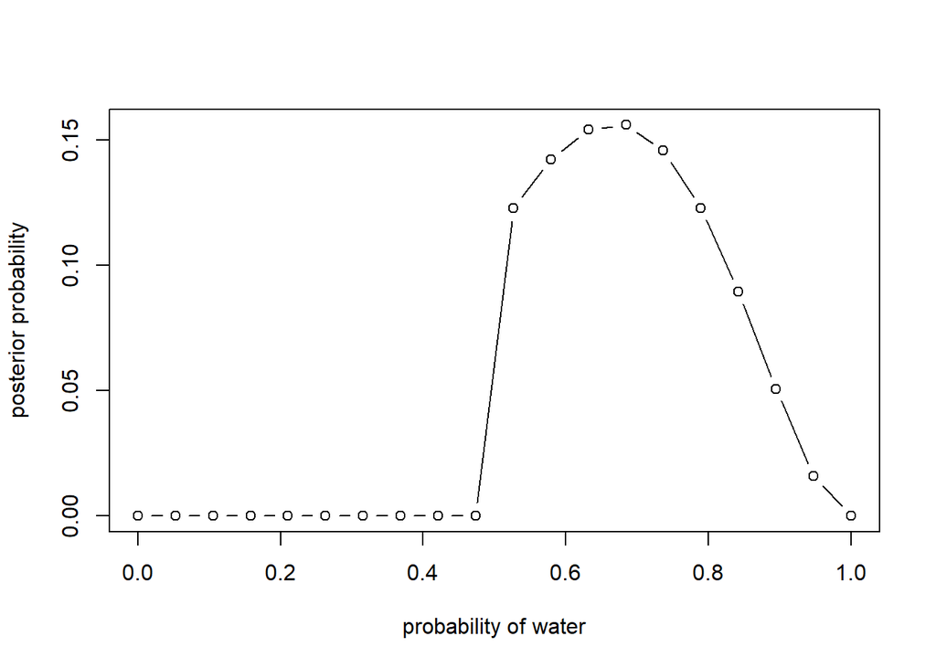

```r
# define grid
p_grid <- seq(from = 0, to = 1, length.out = 20)
# define new prior
newprior <- ifelse(p_grid < 0.5, 0, 1)
# compute likelihood at each value in grid
likelihood <- dbinom(4, size = 6, prob = p_grid)
# compute likelihood of likelihood and prior
unstd.posterior <- likelihood * newprior
# standardize posterior
posterior <- unstd.posterior/sum(unstd.posterior)
# plot
plot(p_grid, posterior, type = "b",
     xlab = "probability of water", ylab = "posterior probability")
```

**Question 3:** For the posterior distribution from question 2, compute 89% percentile and HPDI intervals. Compare the widths of these intervals. Which is wider? Why? If you only had the information in the interval, what might you misunderstand about the shape of the posterior distribution?

*Percentile Intervals:*

```
##        5%       94%
## 0.5263158 0.8947368
```

*HPDI Intervals:*

```
##     |0.89     0.89|
## 0.5263158 0.8421053
```

Response: The percentile interval is wider than the HPDI interval. This is because the percentile interval assigns the same probability mass to each **tail** whereas the HPDI interval calculates the narrowest interval possible containing the specified probability mass (0.89). The interval does not capture the distribution of values so by interpreting only the interval you may misinterpret the probability of certain parameter values.

**Question 4:** OPTIONAL CHALLENGE. Suppose there is bias in sampling so that Land is more likely than Water to be recorded. Specifically, assume that 1-in-5 (20%) of Water samples are accidentally recorded instead as “Land”. First, write a generative simulation of this sampling process. Assuming the true proportion of Water is 0.70, what proportion does your simulation tend to produce instead? Second, using a simulated sample of 20 tosses, compute the unbiased posterior distribution of the true proportion of water.

Response: There is a binomial response of 0 (land) and 1 (water) with a false-negative rate of 0.2 Pr(W|N,*p*)